# Visualizing a cluster analysis in Base `R`

Martin Papenberg

March 25, 2020

This post shows how Base `R` can be used to visualize a cluster analysis in such a way that all clusters can be well distinguished. I use the classical `iris` data set.

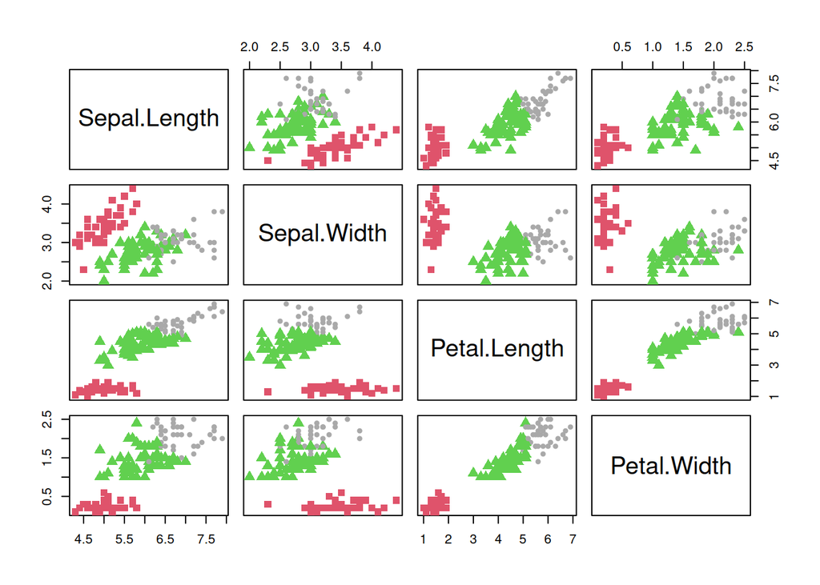

```r
# Load data
data(iris)
cluster_data <- iris[, 1:4]

# Do k-means clustering, store the clustering vector
clusters <- kmeans(cluster_data, 3)$cluster

# define 3 colors, 3 cex values, and 3 pch values that differ between
# clusters - for more clusters, define more values.
colors <- c("#a9a9a9", "#df536b", "#61d04f")
cex <-  c(0.7, 1.2, 1.5)
pch <- c(19, 15, 17)

# Plot the data while visualizing the different clusters
plot(
  cluster_data,
  col = colors[clusters],
  cex = cex[clusters],
  pch = pch[clusters]
)
```

This solution exploits the beautiful indexing capabilities of `R`, seen by the call to the `col`, `cex` and `pch` arguments in `plot()`. The solution requires that the clustering vector is integer and only has values $1, ..., K$ where $K$ is the number of clusters. If a clustering vector `x` has any other form (e.g., is of type `character`), you can convert it to such an integer vector by calling `as.numeric(factor(x))`.

### Anticlustering

As an addon, I also visualize the results of an anticlustering analysis, where instead of maximizing homogeneity within clusters, we maximize heterogeneity within clusters (and equivalently: maximize homogeneity between clusters, i.e., make the different clusters as similar as possible). To this end, I make use of the package [`anticlust`](https://github.com/m-Py/anticlust).

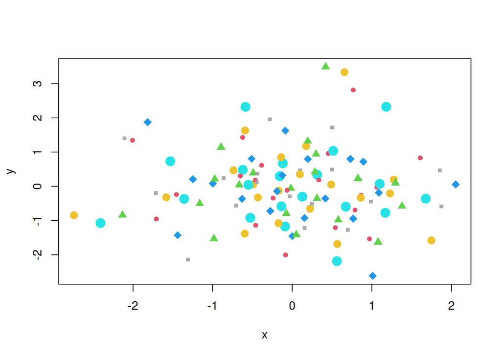

```r
library(anticlust)

# generate some random data, N = 120
data <- data.frame(
  x = rnorm(120),
  y = rnorm(120)
)

# Generate 6 anticlusters that are as similar as possible
groups <- anticlustering(
  data,
  K = 6
)

# define 6 colors, 6 cex values, and 6 pch values:
colors <- c("#a9a9a9", "#df536b", "#61d04f", "#2297e6", "#28e2e5", "#eec12f")
cex <-  c(0.7, 0.9, 1.2, 1.5, 1.7, 2)
pch <- 15:20
plot(
  data,
  col = colors[groups],
  cex = cex[groups],
  pch = pch[groups]
)
```

As we can see, anticlustering is a lot more messy than clustering. All 6 groups overlap to a large degree. This is what anticlustering does: the groups should be similar to each other, as opposed to cluster analysis that seeks groups that are dissimilar from each other.

Last updated: 2020-10-22